# Assignment 4

## Assignment 4: Creating graphs for your data

### author: Jizong Liang Date: 10/11/2015

### import the libraries and the entire dataset to memory

```python
%matplotlib inline
```

```python
import pandas
import numpy as np
import seaborn as sn
import matplotlib.pyplot as plt
```

### some house keeping

- Import the dataset
- convert all variable names to lowercaes
- set avoid run time error message

```python
print("Import the entire dataset to memory")
data = pandas.read_csv("gapminder.csv", low_memory = False)

print("upper case all DataFrame column names")
data.columns = map(str.lower, data.columns)

print("avoid run time error message")
pandas.set_option('display.float_format', lambda x:'%f'%x)
```

### convert string to numerics and set missing values to "nan"

```python
print("convert strings to numerics")
data['incomeperperson'] = data['incomeperperson'].convert_objects(convert_numeric=True)
data['lifeexpectancy'] = data['lifeexpectancy'].convert_objects(convert_numeric=True)
data['alcconsumption'] = data['alcconsumption'].convert_objects(convert_numeric=True)
data['relectricperperson'] = data['relectricperperson'].convert_objects(convert_numeric=True)
data['urbanrate'] = data['urbanrate'].convert_objects(convert_numeric=True)
data['internetuserate'] = data['internetuserate'].convert_objects(convert_numeric=True)
data['hivrate'] = data['hivrate'].convert_objects(convert_numeric=True)

print("Set mission data to NAN")
data['incomeperperson'] = data['incomeperperson'].replace(0, numpy.nan)
data['alcconsumption'] = data['alcconsumption'].replace(0, numpy.nan)
data["lifeexpectancy"] = data["lifeexpectancy"].replace(0, numpy.nan)
data["relectricperperson"] = data["relectricperperson"].replace(0, numpy.nan)
data['urbanrate'] = data['urbanrate'].replace(0, numpy.nan)
data["internetuserate"] = data["internetuserate"].replace(0, numpy.nan)
data['hivrate'] = data['hivrate'].replace(0, numpy.nan)
```

### Create a subset of the dataset and name it as sub2 and preview the subset

```python
print('create sub2 dataset to include only variables of interest.')
sub2 = data[['alcconsumption','lifeexpectancy','relectricperperson','urbanrate', 'internetuserate','hivrate','incomeperperson']]
print('preview dataset')
print(sub2.head(n=10))
```

### create a new varible Income Categories

| income category | income(dollars) |
| --- | --- |
| Low income | 1,035 or less |
| Lower middle | 1,036 to 4,085 |
| Upper middle | 4,086 to 12,615 |
| High income | 12,616 or more |

The categories table above is based on the worldbank official website, see [source](http://data.worldbank.org/news/new-country-classifications)

#### Note: ignore the error message below

```python
def INCOMECATAGO(row):
    if row['incomeperperson'] <= 1035:
        return 1
    elif 1035 < row['incomeperperson']  <= 4085:
        return 2
    elif 4085 < row['incomeperperson'] <= 12615:
        return 3
    else:
        return 4

sub2['INCOMECATAGO'] = sub2.apply(lambda row: INCOMECATAGO(row), axis=1)

sub2['INCOMECATAGO'] = sub2['INCOMECATAGO'].astype('category')

sub2['INCOMECATAGO'] = sub2['INCOMECATAGO'].cat.rename_categories(['low','lower middle', 'upper middle','high'])
```

### preview the entire dataset

```python
print(sub2.head(n=10))
```

[output not shown]

[output cut: 20 more lines]

### Make a categorical count plot for the different income groups.

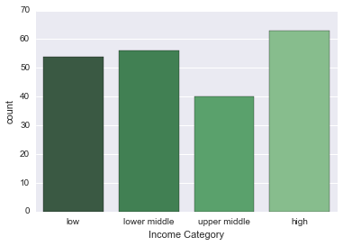

```python
sn.countplot(x='INCOMECATAGO', data = sub2, palette = 'Greens_d')
plt.xlabel("Income Category")
plt.ylabel("count")
plt.show(block=True)
```

### Generate more predictors

Use the same technique to generate new varibles in the same 2 levels categorical format. It includes HIV rate, Life expectancy, Urban rate.

| predictor | level 1 | level 2 |
| --- | --- | --- |
| HIV rate | normal | generalized epidemic |
| Life expectancy | < 70 year old | =>70 year old |
| Urban rate | < 50% | => 50% |

For the HIV rate predictor, see the following detail

There is either a generalised or concentrated epidemic. In a generalised epidemic, HIV prevalence is 1% or more in the general population. In a concentrated or low level epidemics, HIV prevalence is below 1% in the general population but exceeds 5% in specific at-risk populations like injecting drug users or sex workers, or HIV prevalence is not recorded at a significant level in any group).

see [source](http://www.who.int/hiv/topics/surveillance/2ndgen/en/) from WHO website.

**note** ignore the error messages from the outcome

```python
## setting HIV predictor
def HIVPrev(row):
    if row['hivrate'] > 1:
        return 1
    else:
        return 0

sub2['HIVPrev'] = sub2.apply(lambda row: HIVPrev(row), axis=1)

## setting life expectancy predictor
def LIFEexp(row):
    if row['lifeexpectancy'] > 70:
        return 1
    else:
        return 0

sub2['LIFEexp'] = sub2.apply(lambda row: LIFEexp(row), axis=1)

## setting urban rate predictor
def URBAN(row):
    if row['urbanrate'] > 50:
        return 1
    else:
        return 0

sub2['URBAN'] = sub2.apply(lambda row: URBAN(row), axis=1)
```

### examine the newly created varibles

```python
print(sub2.head(n=5))
```

```
   alcconsumption  lifeexpectancy  relectricperperson  urbanrate  \
0        0.030000       48.673000                 nan  24.040000
1        7.290000       76.918000          636.341383  46.720000
2        0.690000       73.131000          590.509814  65.220000
3       10.170000             nan                 nan  88.920000
4        5.570000       51.093000          172.999227  56.700000

   internetuserate  hivrate  incomeperperson  INCOMECATAGO  HIVPrev  LIFEexp  \
0         3.654122      nan              nan          high        0        0
1        44.989947      nan      1914.996551  lower middle        0        1
2        12.500073 0.100000      2231.993335  lower middle        0        1
3        81.000000      nan     21943.339898          high        0        0
4         9.999954 2.000000      1381.004268  lower middle        1        0

   URBAN
0      0
1      0
2      1
3      1
4      1
```

### Income/Person v.s HIV prevalence

from the plot, it indicates that the higher the Income/Person the less HIV rate.

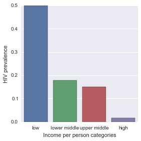

```python
# bivariate bar graph C->C income person vs HIV
sn.factorplot(x='INCOMECATAGO',y="HIVPrev",data=sub2,kind='bar',ci=None)
plt.xlabel('Income per person categories')
plt.ylabel('HIV prevalence')
plt.show()
```

### Income/Person v.s life expectancy

from the plot, it indicates that the longest left expectancy is located in the countries belonged to the upper middle class income level. Which seems to make sense.

```
<function matplotlib.pyplot.show>
```

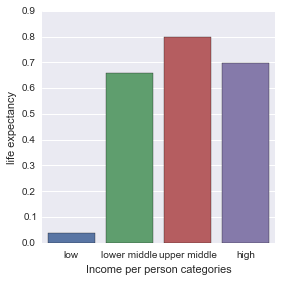

```python
# bivariate bar graph C->C income person vs life expectancy
sn.factorplot(x='INCOMECATAGO',y="LIFEexp",data=sub2,kind='bar',ci=None)
plt.xlabel('Income per person categories')
plt.ylabel('life expectancy')
plt.show
```

### Income/Person v.s Urban rate

The plot indicates that the highest urban rate is located in the countries belonged to the upper middle class level.

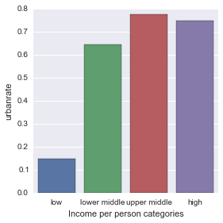

```python
# bivariate bar graph C->C income person vs urbanrate
sn.factorplot(x='INCOMECATAGO',y="URBAN",data=sub2,kind='bar',ci=None)
plt.xlabel('Income per person categories')
plt.ylabel('urbanrate')
plt.show()
```

## quantitative variables graphing study

### Describe each of the quantitative variables

```python
desc1 = sub2['incomeperperson'].describe()
print(desc1)
desc2 = sub2['alcconsumption'].describe()
print(desc2)
desc3 = sub2['lifeexpectancy'].describe()
print(desc3)
desc4 = sub2['relectricperperson'].describe()
print(desc4)
desc5 = sub2['urbanrate'].describe()
print(desc5)
desc6 = sub2['internetuserate'].describe()
print(desc6)
desc7 = sub2['hivrate'].describe()
print(desc7)
```

```
count      190.000000
mean      8740.966076
std      14262.809083
min        103.775857
25%        748.245151
50%       2553.496056
75%       9379.891165
max     105147.437697
Name: incomeperperson, dtype: float64
count   187.000000
mean      6.689412
std       4.899617
min       0.030000
25%       2.625000
50%       5.920000
75%       9.925000
max      23.010000
Name: alcconsumption, dtype: float64
count   191.000000
mean     69.753524
std       9.708621
min      47.794000
25%      64.447000
50%      73.131000
75%      76.593000
max      83.394000
Name: lifeexpectancy, dtype: float64
count     131.000000
mean     1217.956819
std      1697.357982
min         9.192395
25%       247.744304
50%       617.925552
75%      1530.258203
max     11154.755033
Name: relectricperperson, dtype: float64
count   203.000000
mean     56.769360
std      23.844933
min      10.400000
```

[output cut: 8 more lines]

```
min       0.210066
25%       9.999604
50%      31.810121
75%      56.416046
max      95.638113
Name: internetuserate, dtype: float64
count   147.000000
mean      1.935442
std       4.376727
min       0.060000
25%       0.100000
50%       0.400000
75%       1.300000
max      25.900000
Name: hivrate, dtype: float64
```

From the description above, we can see that the variable "income/person" has a large variability, because it has a very large standard variation(sd = 14262.81)

### urban rate v.s internet users rate

The plot indicates that the two variables have a positive correlated relationship.

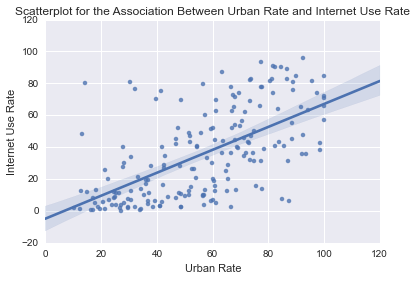

```python
scat1 = sn.regplot(x='urbanrate',y='internetuserate', fit_reg=True, data=sub2)
plt.xlabel('Urban Rate')
plt.ylabel('Internet Use Rate')
plt.title("Scatterplot for the Association Between Urban Rate and Internet Use Rate")
plt.show()
```

The plot indicates that the two variables have a positive correlated relationship, although the correlation might not be very high based on the slope of the fittin line.

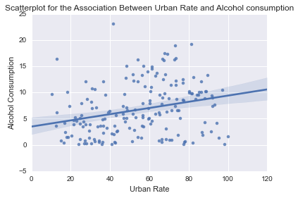

```python
scat2 = sn.regplot(x='urbanrate',y='alcconsumption', fit_reg=True, data=sub2)
plt.xlabel('Urban Rate')
plt.ylabel('Alcohol Consumption')
plt.title("Scatterplot for the Association Between Urban Rate and Alcohol consumption")
plt.show()
```

### Scatterplot for the Association Between Income/Person and HIV rate

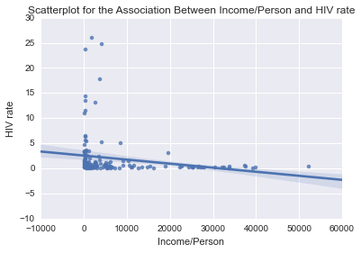

```python
scat3 = sn.regplot(x='incomeperperson',y='hivrate', fit_reg=True, data=sub2)
plt.xlabel('Income/Person')
plt.ylabel('HIV rate')
plt.title("Scatterplot for the Association Between Income/Person and HIV rate")
plt.show()
```

#### Making a categorical plot by converting a quantitive variable into a categorical variable

From the plot, we see that the scatter plot does not do a good job illustrating the two variables, so we create another plot by binning the income/person variable into 4 percentile groups. And bin the HIV rate varible into 2 groups, generalized epidemic and normal.

And according to the WHO, There is either a generalised or concentrated epidemic. In a generalised epidemic, HIV prevalence is 1% or more in the general population. In a concentrated or low level epidemics, HIV prevalence is below 1% in the general population but exceeds 5% in specific at-risk populations like injecting drug users or sex workers, or HIV prevalence is not recorded at a significant level in any group).

see [source](http://www.who.int/hiv/topics/surveillance/2ndgen/en/) from WHO website.

```python
print('Income per person - 4 categories - quartiles')
sub2['INCOMEGRP4'] = pandas.qcut(sub2.incomeperperson, 4, labels=["1=25th%tile","2=50%tile","3=75%tile","4=100%tile"])
c10 = sub2['INCOMEGRP4'].value_counts(sort=False,dropna=True)
print(c10)
```

```
Income per person - 4 categories - quartiles
1=25th%tile    48
2=50%tile      47
3=75%tile      47
4=100%tile     48
dtype: int64
```

#### Use the two newly created categorical varibles, income/person and HIV prevalence to plot a bar chart.

It indicates that lower income countries has higher HIV prevalance thus it indicates HIV epidemic in those countries.

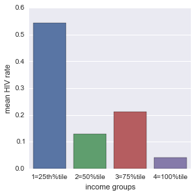

```python
sn.factorplot(x='INCOMEGRP4',y = 'HIVPrev', data=sub2, kind = 'bar', ci=None)
plt.xlabel('income groups')
plt.ylabel('mean HIV rate')
plt.show()
```

### scatter plot for Income/person and Alcohol Consumption

The plot does not indicate a very well correlated relationship between the varibles.

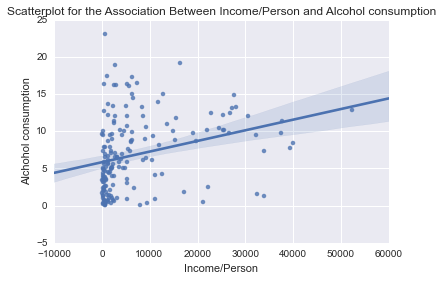

```python
scat4 = sn.regplot(x='incomeperperson',y='alcconsumption', fit_reg=True, data=sub2)
plt.xlabel('Income/Person')
plt.ylabel('Alchohol consumption')
plt.title("Scatterplot for the Association Between Income/Person and Alcohol consumption")
plt.show()
```

### scatter plot for life expectancy and alcohol consumption

The plot indiates a positive correlated relationship between the two vairbles, but it has a lot of varibility.

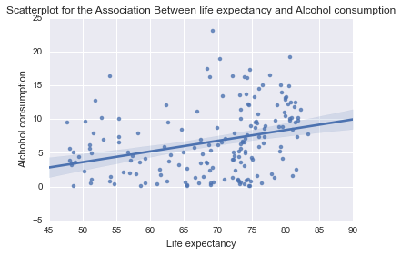

```python
scat5 = sn.regplot(x='lifeexpectancy',y='alcconsumption', fit_reg=True, data=sub2)
plt.xlabel('Life expectancy')
plt.ylabel('Alchohol consumption')
plt.title("Scatterplot for the Association Between life expectancy and Alcohol consumption")
plt.show()
```

All the analysis above is only basic data exploratory, and further study has to be performed as I learn more and more about Python.